# Dose Response - Example Custom Code

Renuka R. Nayak

8/20/2020

# 1 Introduction

This R markdown document provides code used in the analysis of 16S-seq data from gnotobiotic mice humanized with stool from a heathy donor and then subsequently treated with either PBS, low dose or high dose methotrexate (MTX). The results of this experiment as well as other similar experiments are from our manuscript:

Nayak et al, Methotrexate impacts conserved pathways in diverse human gut bacteria leading to decreased host immune activation. In revision.

# 2 Experimental Design

From our mansucript:

“We colonized germ-free mice with a stool sample collected from a healthy human male (Donor 1; Tables S1A and S1B) prior to the oral administration of vehicle, low-dose MTX (1 mg/kg), or high-dose MTX (50 mg/kg), selected to span doses used to treat arthritis (Koyama et al., 2017) and cancer (Chabner and Young, 1973) in murine models (see Methods). Daily stool samples and endpoint samples from the cecum and colon were analyzed using 16S rRNA gene sequencing (16S-seq; Tables S2A and S2B) and quantitative PCR (qPCR), and daily weights were assessed (Table S3A).”

## 2.1 Analysis Notes

Some of the code in this document has been adapted from: https://f1000researchdata.s3.amazonaws.com/manuscripts/10545/387d9a79-c4ab-4676-8466-583e3fb2c85f_8986_-_susan_holmes_v2.pdf?doi=10.12688/f1000research.8986.2

## 2.2 Manuscript Results

# 3 Set Up

## 3.1 Load Libraries

```r
knitr::opts_chunk$set(
    echo = TRUE,
    message = FALSE,
    warning = FALSE
)
library(phyloseq); packageVersion("phyloseq")
```

```
## [1] '1.30.0'
```

```r
library(ggplot2); packageVersion("ggplot2")
```

```
## [1] '3.3.0'
```

```r
library(ape)
library(readxl)
library(ggthemes)
library(tidyverse)
library(RColorBrewer)
library(qiime2R)

set.seed(100)

theme_set(theme_classic(base_size = 9) +theme(axis.text = element_text(colour = "black"), legend.position="right", strip.background = element_blank()))
```

## 3.2 Set Path Names

Set path names where the data and results will be found (variables path and f):  
`path=<parent directory where QIIME2 pipeline results are found>` `f=<metadata file containing information about each sample>`

## 3.3 Obtain Data from the QIIME2 Pipeline

Within QIIME2, taxonomy was assigned using the DADA2 (Callahan et al., 2016a) implementation of the RDP Naïve Bayesian classifier (Wang et al., 2007) using the DADA2-formatted SILVA v128 training set; taxonomic assignments to the species level were chosen by exact match of the ASV to the reference database, and where multiple matches were present, all are reported.

```r
SVtable=read_qza(paste0(path,"SVtable.qza"))
SVseq=read_qza(paste0(path,"SVsequences.qza"))
SVtree=read_qza(paste0(path,"SVtree_denovo.qza"))
taxonomy=read_tsv(paste0(path,"SV_taxonomy_Dada2.txt"))
#add md5 as rownames
taxonomy=taxonomy %>% left_join(as.data.frame(SVseq$data) %>%
                                  rownames_to_column("md5"),
                                by=c("SV"="x"))
rownames(taxonomy)=taxonomy$md5
taxonomy=as.matrix(taxonomy)[,c(2:8,1)] #rearrange to help with tax_glom


sampleDF <- read.delim(f, sep='\t', header=TRUE, row.names = 1)
sampleDF$TimePointAsFactor <- as.factor(sampleDF$TimePoint)

#Using a look up table to assign unique ASV identifiers across all experiments
bigTaxTable=readRDS("bigTaxTable_145789exVivo1012 copy_20200629.RDS")
```

## 3.4 Create Phyloseq Object

```r
# Construct phyloseq object
physeq<-phyloseq(
  otu_table(SVtable$data, taxa_are_rows = T),
  phy_tree(SVtree$data),
  tax_table(taxonomy),
  sample_data(sampleDF %>% as.data.frame()))
physeq <- subset_taxa(physeq, !is.na(Phylum) & !Phylum %in% c("", "uncharacterized")  & !Kingdom %in% c("Eukaryota"))

ps <- physeq

#subset for samples of interest
ps <- subset_samples(ps, Replicate=="no" & Site=="Feces" & TimePoint>-1)
ps
```

```
## phyloseq-class experiment-level object
## otu_table()   OTU Table:         [ 454 taxa and 45 samples ]
## sample_data() Sample Data:       [ 45 samples by 24 sample variables ]
## tax_table()   Taxonomy Table:    [ 454 taxa by 8 taxonomic ranks ]
## phy_tree()    Phylogenetic Tree: [ 454 tips and 453 internal nodes ]
```

```r
#filter taxa based on the number of counts found in that taxa
ps = filter_taxa(ps, function(x) sum(x) > 10, TRUE)
ps
```

```
## phyloseq-class experiment-level object
## otu_table()   OTU Table:         [ 322 taxa and 45 samples ]
## sample_data() Sample Data:       [ 45 samples by 24 sample variables ]
## tax_table()   Taxonomy Table:    [ 322 taxa by 8 taxonomic ranks ]
## phy_tree()    Phylogenetic Tree: [ 322 tips and 321 internal nodes ]
```

```r
rank_names(ps)
```

```
## [1] "Kingdom" "Phylum"  "Class"   "Order"   "Family"  "Genus"   "Species"
## [8] "SV"
```

```r
table(tax_table(ps)[, "Phylum"], exclude = NULL)
```

```
##
##  Actinobacteria   Bacteroidetes   Cyanobacteria      Firmicutes  Proteobacteria
##              12              30               4             268               7
## Verrucomicrobia
##               1
```

```r
#remove taxa that are uncharacterized at the phylum level and unlikely assignments
ps0 <- subset_taxa(ps, !is.na(Phylum) & !Phylum %in% c("", "uncharacterized")  & !Kingdom %in% c("Eukaryota"))

#keep taxa that are uncharacterized at the phylum level
ps0 <- ps0
```

# 4 Fecal Microbiome Analysis

## 4.1 Examine Phylums Represented

```r
#From the phyloseq workflow on F1000
#Compute prevalence of each feature, store as data.frame
prevdf = apply(X = otu_table(ps0),
               MARGIN = ifelse(taxa_are_rows(ps0), yes = 1, no = 2),
               FUN = function(x){sum(x > 0)})

# Add taxonomy and total read counts to this data.frame
prevdf = data.frame(Prevalence = prevdf,
                    TotalAbundance = taxa_sums(ps0),
                    tax_table(ps0))

plyr::ddply(prevdf, "Phylum", function(df1){cbind(mean(df1$Prevalence),sum(df1$Prevalence))})
```

```
##            Phylum        1    2
## 1  Actinobacteria 28.58333  343
## 2   Bacteroidetes 34.36667 1031
## 3   Cyanobacteria 42.25000  169
## 4      Firmicutes 23.05224 6178
## 5  Proteobacteria 42.00000  294
## 6 Verrucomicrobia 45.00000   45
```

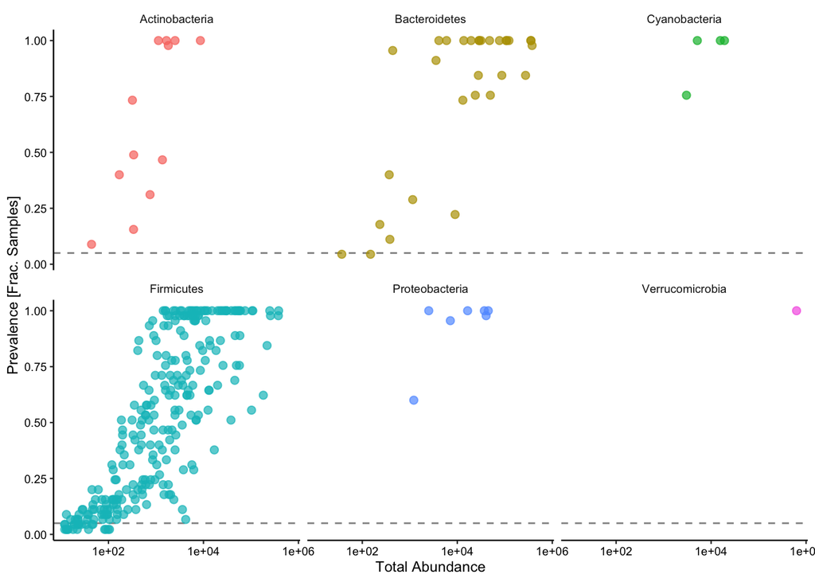

```r
# Subset to the remaining phyla
prevdf1 = subset(prevdf, Phylum %in% get_taxa_unique(ps0, "Phylum"))

ggplot(prevdf1, aes(TotalAbundance, Prevalence / nsamples(ps0),color=Phylum)) +
  # Include a guess for parameter
  geom_hline(yintercept = 0.05, alpha = 0.5, linetype = 2) + geom_point(size = 2, alpha = 0.7) +
  scale_x_log10() + xlab("Total Abundance") + ylab("Prevalence [Frac. Samples]") +
  facet_wrap(~Phylum) + theme(legend.position="none")
```

```r
# Define prevalence threshold as 5% of total samples
prevalenceThreshold = 0.05 * nsamples(ps0)
prevalenceThreshold
```

```
## [1] 2.25
```

```r
#Report number in each taxanomic rank
for (i in rank_names(ps)) {
  print(paste("Number of ",i,":",sep=""))
  print(length(get_taxa_unique(ps0, taxonomic.rank = i)))
}
```

```
## [1] "Number of Kingdom:"
## [1] 1
## [1] "Number of Phylum:"
## [1] 6
## [1] "Number of Class:"
## [1] 13
## [1] "Number of Order:"
## [1] 14
## [1] "Number of Family:"
## [1] 25
## [1] "Number of Genus:"
## [1] 76
## [1] "Number of Species:"
## [1] 58
## [1] "Number of SV:"
## [1] 322
```

## 4.2 Transform Data

Create transformed versions of the data to perform subsequent analyses.

```r
#Convenience functions for geometric mean and clr transform
gm_mean = function(x, na.rm=TRUE){
  # The geometric mean, with some error-protection bits.
  exp(sum(log(x[x > 0 & !is.na(x)]), na.rm=na.rm) / length(x))
  }

#holmes method
clr1 = function(x, base=2){
  x <- log((x / gm_mean(x)), base)
  x[!is.finite(x) | is.na(x)] <- 0.0
  return(x)
  }

#alternative clr method - adding a pseudocount of 1 to values that are 0
clr2 = function(x, base=2){
  x <- log((x / gm_mean(x)), base)
  x[!is.finite(x) | is.na(x)] <- log((1 / gm_mean(x)), base)
  return(x)
}

#set clr function to see if this affects overall results.
clr=clr1

#clr transform data for PCA, multivariate analysis, visualization
ps_clr <- transform_sample_counts(ps0, clr )

#proportion data for visualization
ps_prop <- transform_sample_counts(ps0, function (x) x/sum(x))

#rarefied data for ANOSIM and PERMANOVA
set.seed(25123)
ps_rarefied <- rarefy_even_depth(ps0, sample.size=min(sample_sums(ps0)))
```

## 4.3 Alpha Diversity

Microbial richness (Figure 1B) was comparable between groups.

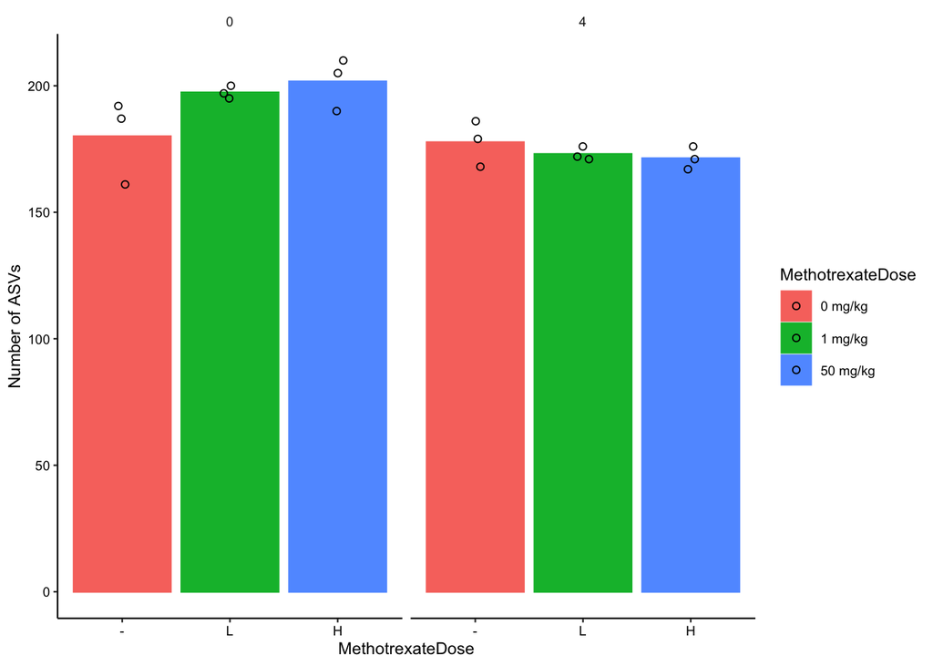

```r
#average richness among replicates over time and generate plots (bars and lines)
ps_t <- ps_rarefied
er1 <- estimate_richness(ps_t,split=TRUE)
er2 <- left_join(rownames_to_column(er1), rownames_to_column(sampleDF), by="rowname")

#plot richness measurements at end of 4 day period for single measurement
print(ggplot(filter(er2,TimePointAsFactor %in% c(0,4)),
             aes(x=MethotrexateDose,y=Observed,group=MethotrexateDose,color=MethotrexateDose, fill=MethotrexateDose))+
        geom_bar(stat = "summary", fun = "mean") +
        geom_jitter(width=0.06,height=0, shape=1, color="black") +
        ylab("Number of ASVs") +
        facet_grid(~TimePointAsFactor) +
        scale_x_discrete(labels=c("0 mg/kg" = "-",
                                  "1 mg/kg" = "L",
                                  "50 mg/kg" = "H")))
```

## 4.4 Beta Diversity

Examine PCA plots using clr transformed data.

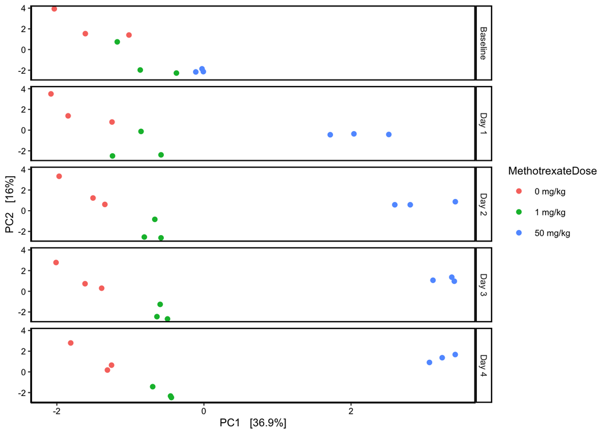

```r
#using clr transform for PCA analysis
day_text <- c(
  `0` = "Baseline",
  `1` = "Day 1",
  `2` = "Day 2",
  `3` = "Day 3",
  `4` = "Day 4"
)

ps_t <- ps_clr
PS.ord <- ordinate(ps_t, "RDA", "euclidean")
ggP <- plot_ordination(ps_t, PS.ord, type="samples", color="MethotrexateDose") +
  facet_grid(TimePoint~., labeller=labeller(TimePoint=day_text)) +
  theme (panel.border = element_rect(color = "black", fill = NA, size = 1),
         strip.background = element_rect(color = "black", size = 1)) +
  scale_color_manual(values=c("#F8766D", "#00BA38", "#619CFF")) +
  theme(legend.position = "right")
print(ggP)
```

## 4.5 Hypothesis Testing

Perform hypothesis testing to determine whether MTX alters community composition.

### 4.5.1 ANOSIM

```r
#ANOSIM testing - both ANOSIM and PERMANOVA (below) will be done on rarefied data
library("vegan")
packageVersion("vegan")
```

```
## [1] '2.5.6'
```

```r
#using rarefied data for this testing
set.seed(10)
ps_t <- ps_rarefied

#Is composition different even pre-treatment?
ps_ano <- subset_samples(ps_t, TimePoint %in% c(0))
mtx_group = get_variable(ps_ano, "MethotrexateDose")
mtx_ano = anosim(phyloseq::distance(ps_ano, "bray"), mtx_group)
mtx_ano
```

```
##
## Call:
## anosim(x = phyloseq::distance(ps_ano, "bray"), grouping = mtx_group)
## Dissimilarity: bray
##
## ANOSIM statistic R: 0.2346
##       Significance: 0.12
##
## Permutation: free
## Number of permutations: 999
```

```r
#check whether composition changes by methotrexate dose at day 1
ps_ano <- subset_samples(ps_t, TimePoint %in% c(1)) #AT TIMEPOINT Day 1
mtx_group = get_variable(ps_ano, "MethotrexateDose")
mtx_ano = anosim(phyloseq::distance(ps_ano, "bray"), mtx_group)
mtx_ano
```

```
##
## Call:
## anosim(x = phyloseq::distance(ps_ano, "bray"), grouping = mtx_group)
## Dissimilarity: bray
##
## ANOSIM statistic R: 0.5967
##       Significance: 0.006
##
## Permutation: free
## Number of permutations: 999
```

```r
#check whether composition changes by methotrexate dose at day 2
ps_ano <- subset_samples(ps_t, TimePoint %in% c(2)) #AT TIMEPOINT Day 2
mtx_group = get_variable(ps_ano, "MethotrexateDose")
mtx_ano = anosim(phyloseq::distance(ps_ano, "bray"), mtx_group)
mtx_ano
```

```
##
## Call:
## anosim(x = phyloseq::distance(ps_ano, "bray"), grouping = mtx_group)
## Dissimilarity: bray
##
## ANOSIM statistic R: 0.6049
##       Significance: 0.003
##
## Permutation: free
## Number of permutations: 999
```

```r
#check whether composition changes by methotrexate dose at day 3
ps_ano <- subset_samples(ps_t, TimePoint %in% c(3)) #AT TIMEPOINT Day 3
mtx_group = get_variable(ps_ano, "MethotrexateDose")
mtx_ano = anosim(phyloseq::distance(ps_ano, "bray"), mtx_group)
mtx_ano
```

```
##
## Call:
## anosim(x = phyloseq::distance(ps_ano, "bray"), grouping = mtx_group)
## Dissimilarity: bray
##
## ANOSIM statistic R: 0.7531
##       Significance: 0.002
##
## Permutation: free
## Number of permutations: 999
```

```r
#check whether composition changes by methotrexate dose at day 4
ps_ano <- subset_samples(ps_t, TimePoint %in% c(4)) #AT TIMEPOINT Day 4
mtx_group = get_variable(ps_ano, "MethotrexateDose")
mtx_ano = anosim(phyloseq::distance(ps_ano, "bray"), mtx_group)
mtx_ano
```

```
##
## Call:
## anosim(x = phyloseq::distance(ps_ano, "bray"), grouping = mtx_group)
## Dissimilarity: bray
##
## ANOSIM statistic R: 0.7449
##       Significance: 0.006
##
## Permutation: free
## Number of permutations: 999
```

### 4.5.2 PERMANOVA

Composition is different at day 4 based on MTX dose, but not pre-treatment.

```r
# Adonis test to determine whether methotrexate dose influences community composition at day 4.
set.seed(1)
ps_t <- ps_rarefied
ps_perma <-  subset_samples(ps_t, TimePoint %in% c(4))
ps_perma_bray <- phyloseq::distance(ps_perma, method = "bray")

# make a data frame from the sample_data
sampledf <- data.frame(sample_data(ps_perma))
adonis(ps_perma_bray ~ MethotrexateDose, data = sampledf) #not sure why I was previ
```

```
##
## Call:
## adonis(formula = ps_perma_bray ~ MethotrexateDose, data = sampledf)
##
## Permutation: free
## Number of permutations: 999
##
## Terms added sequentially (first to last)
##
##                  Df SumsOfSqs  MeanSqs F.Model      R2 Pr(>F)
## MethotrexateDose  2   0.60104 0.300521  6.3518 0.67921  0.001 ***
## Residuals         6   0.28387 0.047312         0.32079
## Total             8   0.88492                  1.00000
## ---
## Signif. codes:  0 '***' 0.001 '**' 0.01 '*' 0.05 '.' 0.1 ' ' 1
```

```r
print("beta dispersion testing")
```

```
## [1] "beta dispersion testing"
```

```r
beta <- betadisper(ps_perma_bray, sampledf$MethotrexateDose)
permutest(beta) #tests whether differences are due to group dispersions (if they are, then p will be significant)
```

```
##
## Permutation test for homogeneity of multivariate dispersions
## Permutation: free
## Number of permutations: 999
##
## Response: Distances
##           Df   Sum Sq   Mean Sq     F N.Perm Pr(>F)
## Groups     2 0.002903 0.0014516 0.135    999  0.774
## Residuals  6 0.064515 0.0107526
```

## 4.6 Phylum Level Trends

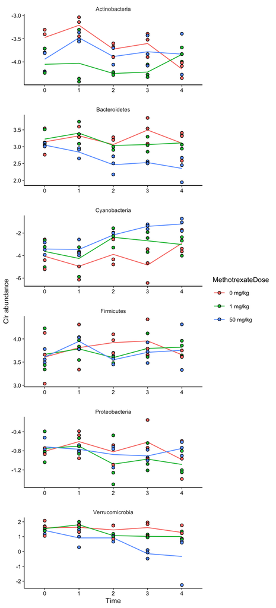

```r
ps_phylum0 = tax_glom(ps0, "Phylum", NArm = TRUE) #agglomerate OTUs by phylum
ps_phylum = transform_sample_counts(ps_phylum0, clr) #CLR transform
ps_phylum_tax_combined_for_plot = psmelt(ps_phylum) #create dataframe for plotting

std <- function(x) sd(x)/sqrt(length(x))

#summarise mean and SEM
ps_phyla_for_plot_mean <- ps_phylum_tax_combined_for_plot %>% group_by(MethotrexateDose,TimePointAsFactor, Phylum) %>% summarise_at(3,mean)
ps_phyla_for_plot_sem <- ps_phylum_tax_combined_for_plot %>% group_by(MethotrexateDose,TimePointAsFactor, Phylum) %>% summarise_at(3,std)
ps_phyla_for_plot_ms <- inner_join(ps_phyla_for_plot_mean, ps_phyla_for_plot_sem, by=c("MethotrexateDose","TimePointAsFactor","Phylum"))

g <- ggplot(data=ps_phyla_for_plot_ms, aes(x=TimePointAsFactor,y=Abundance.x,group=MethotrexateDose,color=MethotrexateDose)) +
  geom_line() +
  geom_point(data=ps_phylum_tax_combined_for_plot, aes(x=TimePointAsFactor,y=Abundance,group=MouseID,fill=MethotrexateDose), shape=21, color="black") +
  facet_wrap(~Phylum, scales="free",nrow=6) + ylab("Clr abundance") + xlab("Time") +
  theme(panel.spacing = unit(1, "lines"))
print(g)
```

## 4.7 DESeq2 Analysis

Determine which taxa are differentially abundant at the ASV, genus, and phylum levels.

We referenced the following: https://www.bioconductor.org/packages/devel/bioc/vignettes/phyloseq/inst/doc/phyloseq-mixture-models.html

### 4.7.1 ASV Level

```r
library(DESeq2)
alpha = 0.01 #SET significance threshold
set.seed(10)

#LOW DOSE COMPARISON
ps_deseq <- ps0
ps_deseq=subset_samples(ps_deseq,
                        MethotrexateDose %in% c("0 mg/kg","1 mg/kg") & TimePoint %in% c(4))
deseq_mtx=phyloseq_to_deseq2(ps_deseq, ~ MethotrexateDose)
geoMeans = apply(counts(deseq_mtx), 1, gm_mean)
deseq_mtx = estimateSizeFactors(deseq_mtx, geoMeans = geoMeans)
deseq_mtx = DESeq(deseq_mtx, test="Wald", fitType="parametric")
res = results(deseq_mtx, cooksCutoff = FALSE)
res2 = cbind(as(res, "data.frame"), as(tax_table(ps_deseq)[rownames(res), ], "matrix"))
sigtab = res[which(res$padj < alpha), ]  #SET significance threshold above
sigtab = cbind(as(sigtab, "data.frame"), as(tax_table(ps_deseq)[rownames(sigtab), ], "matrix"))
dim(sigtab)
```

```
## [1] 26 14
```

```r
print(paste("There are", dim(sigtab)[1],"differentially abundant ASVs with low dose MTX treatment."))
```

```
## [1] "There are 26 differentially abundant ASVs with low dose MTX treatment."
```

```r
sigtab_low <- sigtab
sigtab_low_day4_rsv <- sigtab_low

#HIGH DOSE COMPARISON
ps_deseq <- ps0
ps_deseq=subset_samples(ps_deseq,
                        MethotrexateDose %in% c("0 mg/kg","50 mg/kg") & TimePoint %in% c(4))
deseq_mtx=phyloseq_to_deseq2(ps_deseq, ~ MethotrexateDose)
geoMeans = apply(counts(deseq_mtx), 1, gm_mean)
deseq_mtx = estimateSizeFactors(deseq_mtx, geoMeans = geoMeans)
deseq_mtx = DESeq(deseq_mtx, test="Wald", fitType="parametric")
res = results(deseq_mtx, cooksCutoff = FALSE)
res2 = cbind(as(res, "data.frame"), as(tax_table(ps_deseq)[rownames(res), ], "matrix"))
sigtab = res[which(res$padj < alpha), ] #SET significance threshold above
sigtab = cbind(as(sigtab, "data.frame"), as(tax_table(ps_deseq)[rownames(sigtab), ], "matrix"))
dim(sigtab)
```

```
## [1] 81 14
```

```r
print(paste("There are", dim(sigtab)[1],"differentially abundant ASVs with high dose MTX treatment."))
```

```
## [1] "There are 81 differentially abundant ASVs with high dose MTX treatment."
```

```r
sigtab_high <- sigtab
sigtab_high_day4_rsv <- sigtab_high

overlapping <- intersect(rownames(sigtab_low),rownames(sigtab_high))
length(overlapping)
```

```
## [1] 19
```

```r
print(paste("There are", length(overlapping),"ASVs that are differentially abundant with both low and high dose MTX."))
```

```
## [1] "There are 19 ASVs that are differentially abundant with both low and high dose MTX."
```

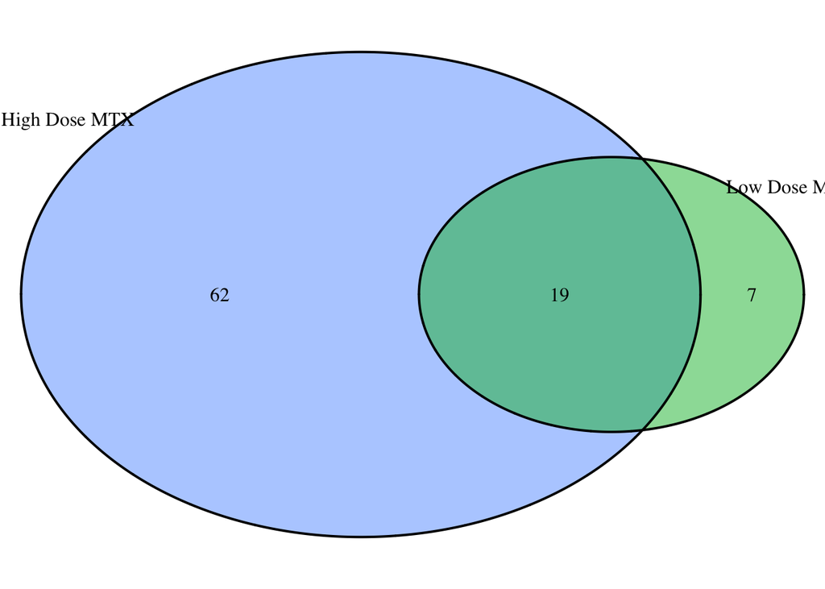

```
## (polygon[GRID.polygon.888], polygon[GRID.polygon.889], polygon[GRID.polygon.890], polygon[GRID.polygon.891], text[GRID.text.892], text[GRID.text.893], text[GRID.text.894], text[GRID.text.895], text[GRID.text.896])
```

```r
library(VennDiagram)
print(draw.pairwise.venn(area1 = 81, area2 = 26, cross.area = 19,
                   category = c("High Dose MTX", "Low Dose MTX"), fill=c("#619CFF","#00BA38")))
```

```r
#hypergeometric test to assess the probability of this overlap occuring by chance
p=1-phyper(19-1,81,241,26) #19 overlapping, 81 successes, 322-81=241 failures, 26 samples
print(paste("The probability of seeing this amount of overlap by chance alone is",p))
```

```
## [1] "The probability of seeing this amount of overlap by chance alone is 1.01555724274505e-07"
```

#### 4.7.1.1 Heatmap Comparing Low and High dose MTX ASVs

Compare ASVs that are differentially abundant with both low and high dose MTX.

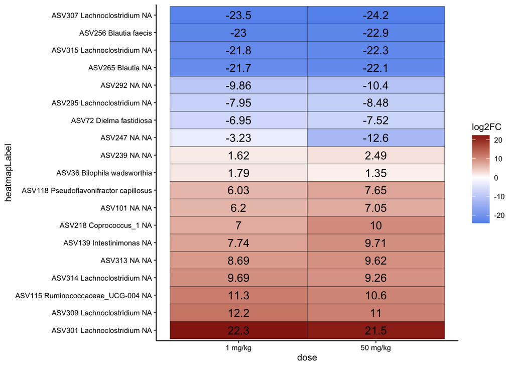

```r
hl <- inner_join(rownames_to_column(sigtab_low),rownames_to_column(sigtab_high),by="rowname")
hl_asvNum=left_join(hl,bigTaxTable %>% rownames_to_column()%>% select(rowname,ASVnum),by="rowname")
hl_asvNum3 <- hl_asvNum %>% select("rowname","log2FoldChange.x","log2FoldChange.y", "ASVnum","Genus.x","Species.x")
colnames(hl_asvNum3)[2:3]=c("1 mg/kg", "50 mg/kg")
hl_asvNum3=hl_asvNum3 %>% mutate(heatmapLabel=str_c(ASVnum,str_replace_na(Genus.x),str_replace_na(Species.x), sep=" "))
hl_asvNum3$heatmapLabel=factor(hl_asvNum3$heatmapLabel, levels=hl_asvNum3$heatmapLabel[order(hl_asvNum3$`1 mg/kg`, decreasing=T)])
hl_asvNum3_m3=gather(hl_asvNum3, 2:3, key="dose", value="log2FC")

ggplot(hl_asvNum3_m3,aes(x=dose, y=heatmapLabel,fill=log2FC)) +
  geom_tile(linejoin="round", color="black")+
  scale_fill_gradient2(midpoint = 0, high = "darkred", mid="white", low = "cornflowerblue") +
  theme(legend.position = "right") +
  geom_text(aes(label=signif(log2FC,3)))
```

### 4.7.2 Genus Level

The code below looks at genera instead of ASVs.

```r
#AGGLOMERATE OVER GENUS to perform DeSeq
#Run only on Day 4 samples

alpha = 0.01 #SET significance threshold

#LOW DOSE COMPARISON
ps_deseq <- tax_glom(ps0, "Genus", NArm = TRUE)
ps_deseq=subset_samples(ps_deseq,
                        MethotrexateDose %in% c("0 mg/kg","1 mg/kg") & TimePoint %in% c(4))
deseq_mtx=phyloseq_to_deseq2(ps_deseq, ~ MethotrexateDose)
geoMeans = apply(counts(deseq_mtx), 1, gm_mean)
deseq_mtx = estimateSizeFactors(deseq_mtx, geoMeans = geoMeans)
deseq_mtx = DESeq(deseq_mtx, test="Wald", fitType="parametric")
res = results(deseq_mtx, cooksCutoff = FALSE)
res2 = cbind(as(res, "data.frame"), as(tax_table(ps_deseq)[rownames(res), ], "matrix"))
sigtab = res[which(res$padj < alpha), ]  #SET significance threshold above
if (dim(sigtab)[1] > 0){
  sigtab = cbind(as(sigtab, "data.frame"), as(tax_table(ps_deseq)[rownames(sigtab), ], "matrix"))
}
dim(sigtab)
```

```
## [1]  2 14
```

```r
print(paste("There are", dim(sigtab)[1],"differentially abundant genera with low dose MTX treatment."))
```

```
## [1] "There are 2 differentially abundant genera with low dose MTX treatment."
```

```r
sigtab_low_genus <- sigtab

#HIGH DOSE COMPARISON
ps_deseq <- tax_glom(ps0, "Genus", NArm = TRUE)
ps_deseq=subset_samples(ps_deseq,
                        MethotrexateDose %in% c("0 mg/kg","50 mg/kg") & TimePoint %in% c(4))
deseq_mtx=phyloseq_to_deseq2(ps_deseq, ~ MethotrexateDose)
geoMeans = apply(counts(deseq_mtx), 1, gm_mean)
deseq_mtx = estimateSizeFactors(deseq_mtx, geoMeans = geoMeans)
deseq_mtx = DESeq(deseq_mtx, test="Wald", fitType="parametric")
res = results(deseq_mtx, cooksCutoff = FALSE)
res2 = cbind(as(res, "data.frame"), as(tax_table(ps_deseq)[rownames(res), ], "matrix"))
sigtab = res[which(res$padj < alpha), ] #SET significance threshold above
sigtab = cbind(as(sigtab, "data.frame"), as(tax_table(ps_deseq)[rownames(sigtab), ], "matrix"))
dim(sigtab)
```

```
## [1] 15 14
```

```r
print(paste("There are", dim(sigtab)[1],"differentially abundant genera with high dose MTX treatment."))
```

```
## [1] "There are 15 differentially abundant genera with high dose MTX treatment."
```

```r
sigtab_high_genus <- sigtab

overlapping <- intersect(rownames(sigtab_low_genus),rownames(sigtab_high_genus))
length(overlapping)
```

```
## [1] 2
```

```r
print(paste("There are", length(overlapping),"genera that are differentially abundant with both low and high dose MTX."))
```

```
## [1] "There are 2 genera that are differentially abundant with both low and high dose MTX."
```

### 4.7.3 Phylum Level

```r
alpha = 0.01 #SET significance threshold

#LOW DOSE COMPARISON
ps_deseq <- tax_glom(ps0, "Phylum", NArm = TRUE)
ps_deseq=subset_samples(ps_deseq,
                        MethotrexateDose %in% c("0 mg/kg","1 mg/kg") & TimePoint %in% c(4))
deseq_mtx=phyloseq_to_deseq2(ps_deseq, ~ MethotrexateDose)
geoMeans = apply(counts(deseq_mtx), 1, gm_mean)
deseq_mtx = estimateSizeFactors(deseq_mtx, geoMeans = geoMeans)
deseq_mtx = DESeq(deseq_mtx, test="Wald", fitType="parametric")
res = results(deseq_mtx, cooksCutoff = FALSE)
res2 = cbind(as(res, "data.frame"), as(tax_table(ps_deseq)[rownames(res), ], "matrix"))
sigtab = res[which(res$padj < alpha), ]  #SET significance threshold above
if (dim(sigtab)[1] > 0){
  sigtab = cbind(as(sigtab, "data.frame"), as(tax_table(ps_deseq)[rownames(sigtab), ], "matrix"))
}
dim(sigtab)
```

```
## [1] 0 6
```

```r
print(paste("There are", dim(sigtab)[1],"differentially abundant phyla with low dose MTX treatment."))
```

```
## [1] "There are 0 differentially abundant phyla with low dose MTX treatment."
```

```r
sigtab_low_phy <- sigtab #nothing significant

#HIGH DOSE COMPARISON
ps_deseq <- tax_glom(ps0, "Phylum", NArm = TRUE)
ps_deseq=subset_samples(ps_deseq,
                        MethotrexateDose %in% c("0 mg/kg","50 mg/kg") & TimePoint %in% c(4))
deseq_mtx=phyloseq_to_deseq2(ps_deseq, ~ MethotrexateDose)
geoMeans = apply(counts(deseq_mtx), 1, gm_mean)
deseq_mtx = estimateSizeFactors(deseq_mtx, geoMeans = geoMeans)
deseq_mtx = DESeq(deseq_mtx, test="Wald", fitType="parametric")
res = results(deseq_mtx, cooksCutoff = FALSE)
res2 = cbind(as(res, "data.frame"), as(tax_table(ps_deseq)[rownames(res), ], "matrix"))
sigtab = res[which(res$padj < alpha), ] #SET significance threshold above
sigtab = cbind(as(sigtab, "data.frame"), as(tax_table(ps_deseq)[rownames(sigtab), ], "matrix"))
dim(sigtab)
```

```
## [1]  1 14
```

```r
print(paste("There are", dim(sigtab)[1],"differentially abundant phyla with high dose MTX treatment."))
```

```
## [1] "There are 1 differentially abundant phyla with high dose MTX treatment."
```

```r
sigtab_high_phy <- sigtab
```

Shows that Bacteroidetes changes at Phylum level using Deseq (with high dose MTX) as well. padj = 0.0009 (nearly 2 fold decrease). Rounded to padj=0.001 in manuscript.

## 4.8 GLMM Analysis

Adapted from: https://github.com/slyalina/Mouse_IBD_2017_paper_supporting_code/blob/master/GLMM_code.Rmd

###Set Up Function

```r
library(cplm)
library(lazyeval)
library(doParallel)
library(R.utils)
library(DT)

glmm_time_trend = function(data, # input dataframe
                           hierarchy1_col, # column name for gene level grouping (ex: "KO")
                           hierarchy2_col = NULL, # column name for pathway level grouping; optional (ex: "module_id")
                           #NOTE: if hierarchy2_col is empty then testing happens on per-gene groups
                           response_col, # column name holding the response variable (ex: "Abundance")
                           time_col, # column name holding numeric time values (ex: "week")
                           group_col, # column name holding factor separating data into groups to be contrasted (ex: "group")
                           cases_label, # value of the group column that correponds to "cases" (ex: "DNR")
                           individual_col, # column name that specifies subjects
                           levels_to_test = NULL, # smaller set of values to test than all levels of ontological grouping
                           extra_covars=c(), # any additonal variables affecting response; optional (ex: "kit")
                           time_out=300, # constrain the time alloted for fitting each model (in seconds)
                           log_file = "") # write intermediate results to log for monitoring, otherwise print to stdout
{

    if(is.null(levels_to_test)){
        if(is.null(hierarchy2_col)){
            levels_to_test = unique(unlist(data[,hierarchy1_col]))
        }
        else{
            levels_to_test = unique(unlist(data[,hierarchy2_col]))
        }
    }
    write(paste(c("name","p_intercept","p_slope","coeff_intercept","coeff_slope"),collapse = " "),file = log_file,append = TRUE)
    glmm_results = foreach(lvl = levels_to_test,
                           .inorder = TRUE,
                           .packages = c("cplm","dplyr","lazyeval","R.utils")
                            ) %dopar% {
        tryCatch({
            # Subset the data to either all the genes in pathway being looekd at,
            # or just the one gene if not doing higher level grouping
            data_here = data %>%
                filter_(interp(~lvl_tested == lvl,
                               lvl_tested = as.name(ifelse(!is.null(hierarchy2_col),
                                                           hierarchy2_col,
                                                           hierarchy1_col))))
            # Assemble model formulas from provided variable names to fit 3 models
            fmla0 = sprintf("%s ~ %s %s %s + (1 + %s | %s) %s",
                            response_col,
                            time_col,
                            ifelse(length(extra_covars) > 0,"+",""),
                            paste(extra_covars,collapse = " + "),
                            time_col,
                            individual_col,
                            ifelse(!is.null(hierarchy2_col),
                                sprintf("+ (1 + %s|%s)",time_col,hierarchy1_col),
                                ""
                            ))
            fmla1 = sprintf("%s ~ %s + %s %s %s + (1 + %s | %s) %s",
                            response_col,
                            time_col,
                            group_col,
                            ifelse(length(extra_covars) > 0,"+",""),
                            paste(extra_covars,collapse = " + "),
                            time_col,
                            individual_col,
                            ifelse(!is.null(hierarchy2_col),
                                sprintf("+ (1 + %s|%s)",time_col,hierarchy1_col),
                                ""
                            ))
            fmla2 = sprintf("%s ~ %s * %s %s %s + (1 + %s | %s) %s",
                            response_col,
                            time_col,
                            group_col,
                            ifelse(length(extra_covars) > 0,"+",""),
                            paste(extra_covars,collapse = " + "),
                            time_col,
                            individual_col,
                            ifelse(!is.null(hierarchy2_col),
                                sprintf("+ (1 + %s|%s)",time_col,hierarchy1_col),
                                ""
                            ))
            fit0 = withTimeout(do.call("cpglmm",list(formula=formula(fmla0),
                                                         data=as.name("data_here"),
                                                         control=list(max.iter=3000,
                                                                      max.fun=20000))),
                                   timeout = time_out,onTimeout = "error")
            fit1 = withTimeout(do.call("cpglmm",list(formula=formula(fmla1),
                                                         data=as.name("data_here"),
                                                         control=list(max.iter=3000,
                                                                      max.fun=20000))),
                                   timeout = time_out,onTimeout = "error")
            fit2 = withTimeout(do.call("cpglmm",list(formula=formula(fmla2),
                                                         data=as.name("data_here"),
                                                         control=list(max.iter=3000,
                                                                      max.fun=20000))),
                                   timeout = time_out,onTimeout = "error")
            anova_res = anova(fit0,fit1,fit2) # does LRT on the set of nested models
            p_vals = anova_res$`Pr(>Chisq)`[2:3]
            coeffs = cplm::fixef(fit2) # take estimates from most complex model
            write(sprintf("%s   %G  %G  %f  %f",lvl,
                          p_vals[1],
                          p_vals[2],
                          coeffs[paste0(group_col,cases_label)],
                          coeffs[paste0(time_col,":",group_col,cases_label)]),
                  file = log_file,append = TRUE)
            return(list(p_interaction = p_vals[2],
                        p_intercept = p_vals[1],
                        coeff_interaction = coeffs[paste0(time_col,":",group_col,cases_label)],
                        coeff_intercept = coeffs[paste0(group_col,cases_label)],
                        fit = list(aov=anova_res,
                                   index=fit2@p,
                                   disp=fit2@phi,
                                   coefs=coeffs)))}
            ,error = function(e) { #If an error ocurred or model fitting timed out return a list of NAs
                write(toString(e), file=log_file, append = TRUE)
                return(list(NA,NA,NA,NA,NA))
            }
        )
}
    names(glmm_results) = levels_to_test
    return(glmm_results)
}
```

### 4.8.1 Application of GLMM Function

Phylum level

```r
#ps_phylum = tax_glom(ps_clr, "Phylum", NArm = TRUE) #agglomerate OTUs by phylum incorrect!
ps_phylum0 = tax_glom(ps0, "Phylum", NArm = TRUE) #agglomerate OTUs by phylum
ps_phylum = transform_sample_counts(ps_phylum0, clr) #agglomerate OTUs by phylum

ps_phylum_otu_table = psmelt(otu_table(ps_phylum))
ps_phylum_tax_table = as(tax_table(ps_phylum),"matrix") %>% as.data.frame() %>% rownames_to_column(.,var="OTU")
ps_phylum_tax_combined = full_join(ps_phylum_otu_table,ps_phylum_tax_table)
a <- rownames_to_column(sampleDF,var="Sample")
ps_phylum_tax_combined_for_plot <- left_join(ps_phylum_tax_combined,a,by="Sample")
df_for_glmm0 <- ps_phylum_tax_combined_for_plot[,c("OTU","Abundance","Phylum","MouseID","TimePoint","MethotrexateDose")]

#compared low dose vs. vehicle
df_for_glmm <- df_for_glmm0[df_for_glmm0$MethotrexateDose %in% c("0 mg/kg","1 mg/kg"),]
df_for_glmm$group = factor(df_for_glmm$MethotrexateDose,levels=c("0 mg/kg","1 mg/kg"))
glmm_results = glmm_time_trend(data = df_for_glmm,
                               hierarchy1_col = "Phylum",
                               response_col = "Abundance",
                               time_col = "TimePoint",
                               group_col = "group",
                               cases_label = "50 mg/kg",
                               individual_col = "MouseID",
                               time_out = 3000)
```

```
## name p_intercept p_slope coeff_intercept coeff_slope
## Firmicutes   0.701467  0.978095  NA  NA
## Bacteroidetes   0.932067  0.268209  NA  NA
## Verrucomicrobia   0.945454  0.0478144  NA  NA
## Error in if (!(validmu(mu) && valideta(eta))) stop("cannot find valid starting values: please specify some", : missing value where TRUE/FALSE needed
##
## Error in if (!(validmu(mu) && valideta(eta))) stop("cannot find valid starting values: please specify some", : missing value where TRUE/FALSE needed
##
## Error in if (!(validmu(mu) && valideta(eta))) stop("cannot find valid starting values: please specify some", : missing value where TRUE/FALSE needed
```

```r
glmm_results = glmm_results[sapply(glmm_results,function(x) !is.na(x[[1]]))] # Removed failed fits
interaction_df = as.data.frame(t(sapply(glmm_results,function(x) c(unname(x[[1]]),unname(x[[3]])))))
colnames(interaction_df) = c("p_value","interaction_coeff")
interaction_df = interaction_df %>%
    mutate(module = rownames(interaction_df))
intercept_df = as.data.frame(t(sapply(glmm_results,function(x) c(unname(x[[2]]),unname(x[[4]])))))
colnames(intercept_df) = c("p_value","intercept_coeff")
intercept_df = intercept_df %>% mutate(
    module = rownames(intercept_df))

datatable(interaction_df)
```

|  | p_value | interaction_coeff | module |
| --- | --- | --- | --- |
| 1 | 0.978094974816085 |  | Firmicutes |
| 2 | 0.268209078310735 |  | Bacteroidetes |
| 3 | 0.0478144082868783 |  | Verrucomicrobia |

```r
#compared high dose vs. vehicle
df_for_glmm <- df_for_glmm0[df_for_glmm0$MethotrexateDose %in% c("0 mg/kg","50 mg/kg"),]
df_for_glmm$group = factor(df_for_glmm$MethotrexateDose,levels=c("0 mg/kg","50 mg/kg"))
glmm_results = glmm_time_trend(data = df_for_glmm,
                               hierarchy1_col = "Phylum",
                               response_col = "Abundance",
                               time_col = "TimePoint",
                               group_col = "group",
                               cases_label = "50 mg/kg",
                               individual_col = "MouseID",
                               time_out = 3000)
```

```
## name p_intercept p_slope coeff_intercept coeff_slope
## Firmicutes   0.535508  0.717439  -0.003204  -0.007465
## Bacteroidetes   0.173276  0.00709461  -0.066504  -0.066619
## Error in if (!(validmu(mu) && valideta(eta))) stop("cannot find valid starting values: please specify some", : missing value where TRUE/FALSE needed
##
## Error in if (!(validmu(mu) && valideta(eta))) stop("cannot find valid starting values: please specify some", : missing value where TRUE/FALSE needed
##
## Error in if (!(validmu(mu) && valideta(eta))) stop("cannot find valid starting values: please specify some", : missing value where TRUE/FALSE needed
##
## Error in if (!(validmu(mu) && valideta(eta))) stop("cannot find valid starting values: please specify some", : missing value where TRUE/FALSE needed
```

```r
glmm_results = glmm_results[sapply(glmm_results,function(x) !is.na(x[[1]]))] # Removed failed fits
interaction_df = as.data.frame(t(sapply(glmm_results,function(x) c(unname(x[[1]]),unname(x[[3]])))))
colnames(interaction_df) = c("p_value","interaction_coeff")
interaction_df = interaction_df %>%
    mutate(module = rownames(interaction_df))
intercept_df = as.data.frame(t(sapply(glmm_results,function(x) c(unname(x[[2]]),unname(x[[4]])))))
colnames(intercept_df) = c("p_value","intercept_coeff")
intercept_df = intercept_df %>% mutate(
    module = rownames(intercept_df))

datatable(interaction_df)
```

|  | p_value | interaction_coeff | module |
| --- | --- | --- | --- |
| 1 | 0.717439321717864 | -0.00746522125485832 | Firmicutes |
| 2 | 0.00709461232286947 | -0.0666189267931848 | Bacteroidetes |

# 5 Ileum, Cecal and Colon Microbiome Analysis

We determine the number of phyla, genera and ASVs that change in each of these three sites with low and high dose MTX treatment (compared to vehicle control): ileum, cecum and colon.

## 5.1 Beta Diversity

```r
physeq<-phyloseq(
  otu_table(SVtable$data, taxa_are_rows = T),
  phy_tree(SVtree$data),
  tax_table(taxonomy),
  sample_data(sampleDF %>% as.data.frame()))

#saveRDS(physeq,paste0(path,"physeqObject.RDS"))
#physeq=readRDS(paste0(path,"physeqObject.RDS"))

ps <- physeq

#filter taxa based on the number of counts found in that taxa
ps = filter_taxa(ps, function(x) sum(x) > 10, TRUE)
ps
```

```
## phyloseq-class experiment-level object
## otu_table()   OTU Table:         [ 393 taxa and 96 samples ]
## sample_data() Sample Data:       [ 96 samples by 24 sample variables ]
## tax_table()   Taxonomy Table:    [ 393 taxa by 8 taxonomic ranks ]
## phy_tree()    Phylogenetic Tree: [ 393 tips and 392 internal nodes ]
```

```r
#remove taxa that are uncharacterized at the phylum level or unlikely assignments
ps <- subset_taxa(ps, !is.na(Phylum) & !Phylum %in% c("", "uncharacterized")  & !Kingdom %in% c("Eukaryota"))
ps
```

```
## phyloseq-class experiment-level object
## otu_table()   OTU Table:         [ 392 taxa and 96 samples ]
## sample_data() Sample Data:       [ 96 samples by 24 sample variables ]
## tax_table()   Taxonomy Table:    [ 392 taxa by 8 taxonomic ranks ]
## phy_tree()    Phylogenetic Tree: [ 392 tips and 391 internal nodes ]
```

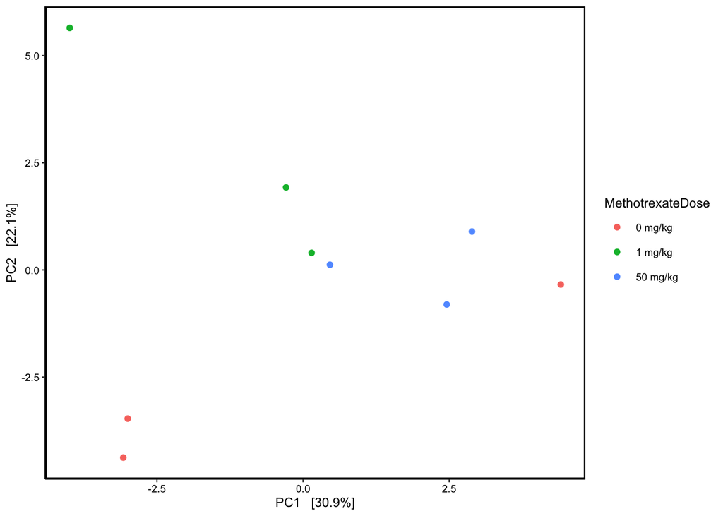

```r
#compare small intestine
ps_ileum <- subset_samples(ps, Replicate=="no" & Site=="Ileum")
#compare cecal samples
ps_cecum <- subset_samples(ps, Replicate=="no" & Site=="Cecum")
#compare large intestine
ps_colon <- subset_samples(ps, Replicate=="no" & Site=="Colon")

#PCA Ileum
ps_t <- transform_sample_counts(ps_ileum, clr )
PS.ord <- ordinate(ps_t, "RDA", "euclidean")
ggP <- plot_ordination(ps_t, PS.ord, type="samples", color="MethotrexateDose") +
  theme_classic(base_size=9) +
  theme (panel.border = element_rect(color = "black", fill = NA, size = 1),
         strip.background = element_rect(color = "black", size = 1),
         axis.text = element_text(colour = "black")) +
  scale_color_manual(values=c("#F8766D", "#00BA38", "#619CFF"))
print(ggP)
```

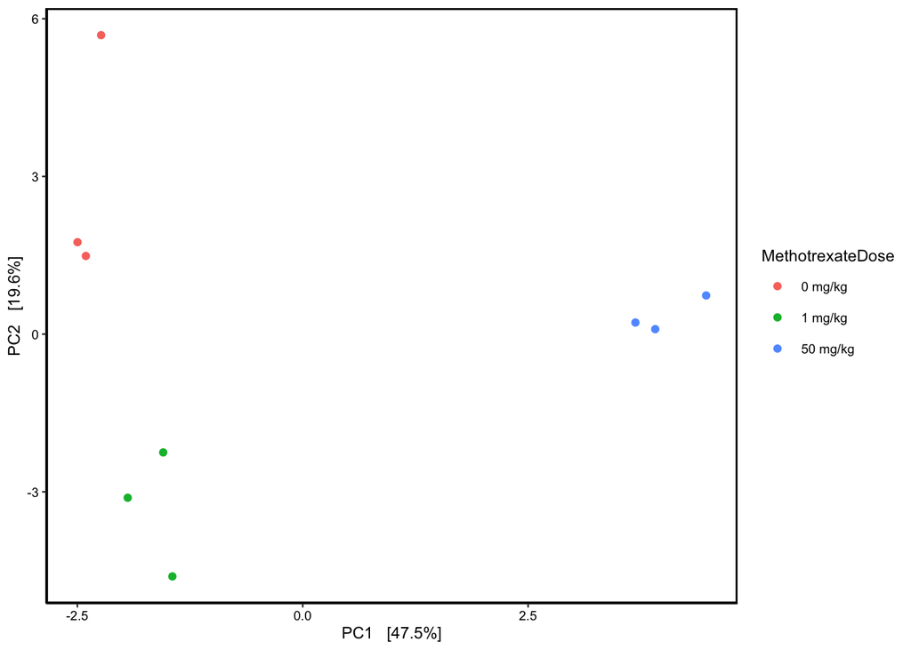

```r
#PCA Cecum
ps_t <- transform_sample_counts(ps_cecum, clr )
PS.ord <- ordinate(ps_t, "RDA", "euclidean")
ggP <- plot_ordination(ps_t, PS.ord, type="samples", color="MethotrexateDose") +
  theme_classic(base_size=9) +
  theme (panel.border = element_rect(color = "black", fill = NA, size = 1),
         strip.background = element_rect(color = "black", size = 1),
         axis.text = element_text(colour = "black")) +
  scale_color_manual(values=c("#F8766D", "#00BA38", "#619CFF"))
print(ggP)
```

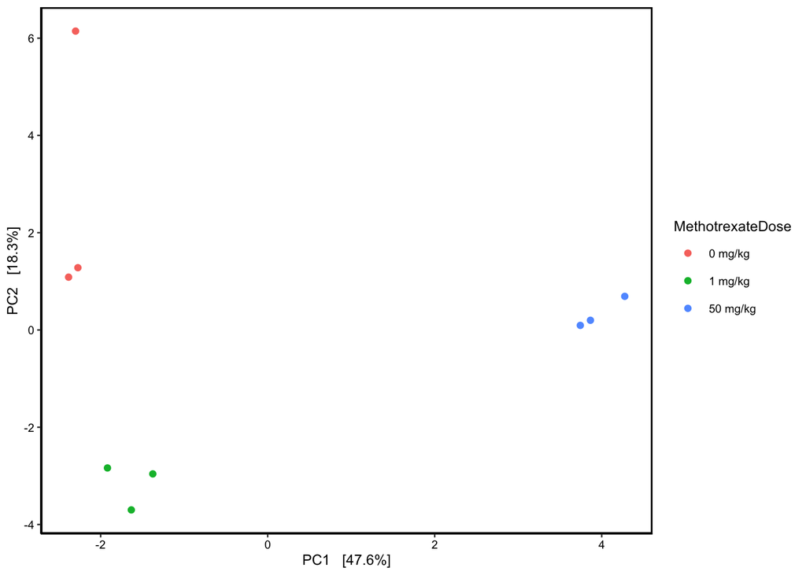

```r
#PCA Colon
ps_t <- transform_sample_counts(ps_colon, clr )
PS.ord <- ordinate(ps_t, "RDA", "euclidean")
ggP <- plot_ordination(ps_t, PS.ord, type="samples", color="MethotrexateDose") +
  theme_classic(base_size=9) +
  theme (panel.border = element_rect(color = "black", fill = NA, size = 1),
         strip.background = element_rect(color = "black", size = 1),
         axis.text = element_text(colour = "black")) +
  scale_color_manual(values=c("#F8766D", "#00BA38", "#619CFF"))
print(ggP)
```

There are clear shifts in community composition in the cecum and colon, but less so in the ileum, perhaps because of low reads relative to the other sites.

## 5.2 Hypothesis Testing

### 5.2.1 ANOSIM

```r
ds <- c(ps_ileum,ps_cecum,ps_colon)

#perform ANOSIM
ano_hypTest <- lapply(ds,
                      function (x) {
                        set.seed(10)
                        ps_rarefied <- rarefy_even_depth(x, sample.size=min(sample_sums(x)))
                        ps_ano <- ps_rarefied
                        mtx_group = get_variable(ps_ano,"MethotrexateDose")
                        mtx_ano = anosim(phyloseq::distance(ps_ano, "bray"), mtx_group)
                        mtx_ano
}
)

for (i in 1:3) {
  print(ano_hypTest[[i]])
}
```

```
##
## Call:
## anosim(x = phyloseq::distance(ps_ano, "bray"), grouping = mtx_group)
## Dissimilarity: bray
##
## ANOSIM statistic R: 0.1029
##       Significance: 0.284
##
## Permutation: free
## Number of permutations: 999
##
##
## Call:
## anosim(x = phyloseq::distance(ps_ano, "bray"), grouping = mtx_group)
## Dissimilarity: bray
##
## ANOSIM statistic R: 0.7695
##       Significance: 0.012
##
## Permutation: free
## Number of permutations: 999
##
##
## Call:
## anosim(x = phyloseq::distance(ps_ano, "bray"), grouping = mtx_group)
## Dissimilarity: bray
##
## ANOSIM statistic R: 0.7366
##       Significance: 0.004
##
## Permutation: free
## Number of permutations: 999
```

### 5.2.2 DESeq

```r
#perform DESeq comparing 0 and high dose
ds_hypTest <- lapply (ds,
                     function (x) {
                     ps_deseq <- x
                     ps_deseq=subset_samples(ps_deseq,
                        MethotrexateDose %in% c("0 mg/kg","50 mg/kg"))
                     deseq_mtx=phyloseq_to_deseq2(ps_deseq, ~ MethotrexateDose)
                     geoMeans = apply(counts(deseq_mtx), 1, gm_mean)
                     deseq_mtx = estimateSizeFactors(deseq_mtx, geoMeans = geoMeans)
                     deseq_mtx = DESeq(deseq_mtx, test="Wald", fitType="parametric")
                     res = results(deseq_mtx, cooksCutoff = FALSE)
                     res2 = cbind(as(res, "data.frame"), as(tax_table(ps_deseq)[rownames(res), ], "matrix"))
                     })



ileum <- as.data.frame(ds_hypTest[1])
cecum <- as.data.frame(ds_hypTest[2])
colon <- as.data.frame(ds_hypTest[3])

alpha=0.01
ds_sigtab <- lapply(ds_hypTest, function(x) {x[x$padj<alpha & !is.na(x$padj),]})
ds_numSig <- sapply(ds_sigtab, function(x) {dim(x)[1]})
print(ds_numSig)
```

```
## [1]  0 77 71
```

```r
ileum_sigtab <- as.data.frame(ds_sigtab[1]) # no significant ASVs
cecum_sigtab <- as.data.frame(ds_sigtab[2]) # 77 significant ASVs
colon_sigtab <- as.data.frame(ds_sigtab[3]) # 71 significant ASVs

#perform DESeq comparing 0 and LOW dose
ds_hypTest_low <- lapply (ds,
                     function (x) {
                     ps_deseq <- x
                     ps_deseq=subset_samples(ps_deseq,
                        MethotrexateDose %in% c("0 mg/kg","1 mg/kg"))
                     deseq_mtx=phyloseq_to_deseq2(ps_deseq, ~ MethotrexateDose)
                     geoMeans = apply(counts(deseq_mtx), 1, gm_mean)
                     deseq_mtx = estimateSizeFactors(deseq_mtx, geoMeans = geoMeans)
                     deseq_mtx = DESeq(deseq_mtx, test="Wald", fitType="parametric")
                     res = results(deseq_mtx, cooksCutoff = FALSE)
                     res2 = cbind(as(res, "data.frame"), as(tax_table(ps_deseq)[rownames(res), ], "matrix"))
                     })

alpha=0.01
ds_sigtab_low <- lapply(ds_hypTest_low, function(x) {x[x$padj<alpha & !is.na(x$padj),]})
ds_numSig_low <- sapply(ds_sigtab_low, function(x) {dim(x)[1]})
print(ds_numSig_low)
```

```
## [1]  6 25 25
```

```r
ileum_sigtab_low <- as.data.frame(ds_sigtab_low[1]) # 6 significant ASVs
cecum_sigtab_low <- as.data.frame(ds_sigtab_low[2]) # 25 significant ASVs
colon_sigtab_low <- as.data.frame(ds_sigtab_low[3]) # 25 significant ASVs

cecum_sigtab_low$dose="low-dose"
cecum_sigtab$dose="high-dose"
cecum_sum=rbind(cecum_sigtab_low,cecum_sigtab)
write_csv(rownames_to_column(cecum_sum),"cecum_summary.csv")

colon_sigtab_low$dose="low-dose"
colon_sigtab$dose="high-dose"
colon_sum=rbind(colon_sigtab_low,colon_sigtab)
write_csv(rownames_to_column(colon_sum),"colon_summary.csv")
```

6, 25, 25 ASVs change with low dose in ileum, cecum, colon 0, 77, 71 ASVs change with high dose in ileum, cecum, colon

# 6 UpSet Plot Comparing ASVs Significant in Feces, Cecum, and Colon

For high dose treatment

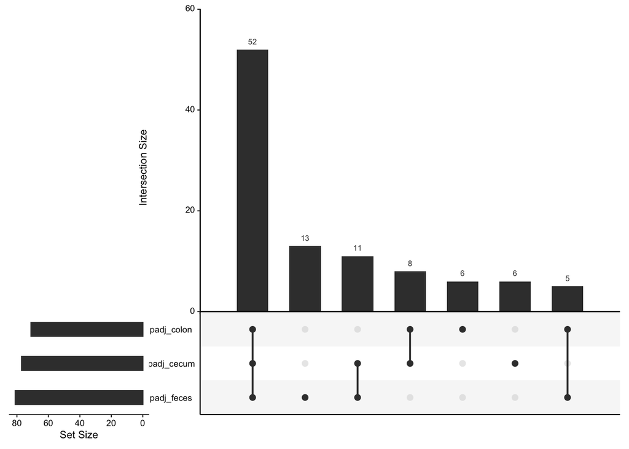

```r
library(UpSetR)
#HIGH DOSE
a <- full_join(rownames_to_column(sigtab_high_day4_rsv)[,c(1,3,7)],
               rownames_to_column(cecum_sigtab)[,c(1,3,7)], by="rowname")
a <- full_join(a,rownames_to_column(colon_sigtab)[,c(1,3,7)],by="rowname")
colnames(a) <- c("rowname","l2fc_feces","padj_feces","l2fc_cecum","padj_cecum","l2fc_colon","padj_colon")
binMatrix=mutate_at(a[,c(3,5,7)], 1:3, funs(ifelse(!is.na(.), 1, 0)))
upset(as.data.frame(binMatrix), sets = c("padj_feces","padj_cecum","padj_colon"), nintersects = NA, keep.order = TRUE, order.by="freq")
```

# 7 Example Code Comments

This code provides an example of how the initial gnotobiotic experiment in which mice were treated with 2 doses of MTX were analyzed. Experiments in which mice were individually housed (Figure S1) as well as the route and rescue experiments (Figure S2) were analyzed in similar ways.

## 7.1 Combined Analysis

For the combined analysis presented in Figure S3, we combined phyloseq objects form the different gnotobiotic experiments in which mice were treated with high dose MTX. We included a variable for experiment or donor as well to determine the impacts of each of these variables and their contributions to community composition.

An example of the DESeq formula used this analysis is:

`deseq_mtx=phyloseq_to_deseq2(ps_deseq, ~ exp+MTXcontrast)` `geoMeans = apply(counts(deseq_mtx), 1, gm_mean)` `deseq_mtx = estimateSizeFactors(deseq_mtx, geoMeans = geoMeans)` `deseq_mtx = DESeq(deseq_mtx, test="Wald", fitType="parametric")`